# act_report

## Analysis of Twitter WeRateDogs Dataset

### Introduction

The dataset that was analyzed and visualized is the twitter WeRateDogs dataset. WeRateDogs is a Twitter account that rates people's dogs with a humorous comment about the dog. These ratings almost always have a denominator of 10 while the numerators are almost always greater than 10. WeRateDogs has over 4 million followers and has received international media coverage.

### Analysis and insights

After data wrangling of the dataset, some analysis was performed mostly in relation to the dog breeds and some insights were drawn.

- First off the breed of the dogs and the frequency they appeared on WeRateDogs tweets where caculated. This showed that the golden retriever was posted the most on WeRateDogs appearing 139 times.
- Secondly the breed of dogs were sorted in descending order according to their ratings. This showed that the dog with the highest rating according to WeRateDogs rating system was a labrador retriever having a rating of 165/10 .
- Finally the breed of dogs were also sorted in descending order but according to their retweets. This also showed that the dog post with the highest retweets of 79515 retweets was also a labrador retriever but not the same labrador retriever with the highest ratings.

### Visualization

The top ten most popular dog breeds were caculated based on the frequency of times these breeds where tweeted about. This was represented with a vertical bar chart in the figure below

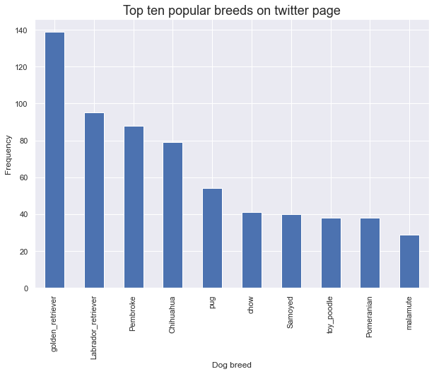

This shows the golden retriever is the most popular dog breed tweeted about on the WeRateDogs Twitter account with a tweet frequency of 139, second to the Labrador retriever at 95, then the Pembroke, Chihuahua, Pug, Chow, Samoyed, Toy poodle, Pomeranian, Malamute Respectively.